# Untitled

2025-08-06

# Introduction to Moving Average (MA) Processes

Moving Average (MA) processes are fundamental time series models where the current value depends on current and past error terms. An MA(q) process is defined as:

$$Y_t = \epsilon_t + \theta_1
\epsilon_{t-1} + \theta_2 \epsilon_{t-2} + ... + \theta_q
\epsilon_{t-q}$$

where $\epsilon_t$ is white noise with $\epsilon_t \sim WN(0, \sigma^2)$ and $\theta_i$ are the moving average parameters.

Key properties of MA processes:

- **Always stationary** (unlike AR processes)
- **Finite memory** - only depends on q past shocks
- **Invertible** when roots of characteristic polynomial lie outside unit circle

```r
# Function to simulate MA process
simulate_ma <- function(n, theta, sigma = 1) {
  q <- length(theta)

  # Generate white noise (we need n + q terms)
  epsilon <- rnorm(n + q, 0, sigma)

  # Initialize MA process
  Y <- numeric(n)

  # Generate MA process
  for (t in 1:n) {
    Y[t] <- epsilon[t + q]  # Current shock
    for (j in 1:q) {
      Y[t] <- Y[t] + theta[j] * epsilon[t + q - j]  # Past shocks
    }
  }

  return(Y)
}

# Simulation parameters
n_obs <- 500
time_points <- 1:n_obs
```

## MA(1) Process

An MA(1) process follows: $Y_t = \epsilon_t + \theta_1 \epsilon_{t-1}$

**Key properties:**

- Mean: $E[Y_t] = 0$
- Variance: $Var(Y_t) = \sigma^2(1 + \theta_1^2)$
- Autocovariance: $\gamma(1) = \theta_1\sigma^2$, $\gamma(k) = 0$ for $k > 1$
- **Finite memory**: only current and previous shock matter

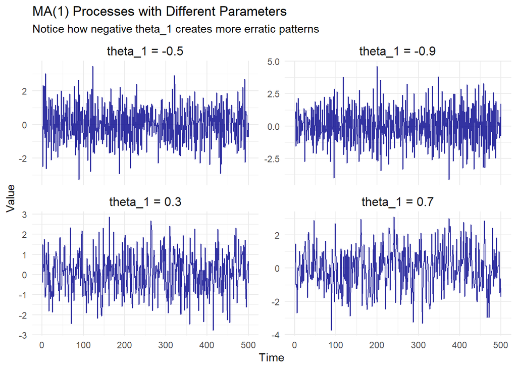

```r
# Different MA(1) parameters
theta1_values <- c(0.3, 0.7, -0.5, -0.9)
ma1_data <- data.frame()

for (theta in theta1_values) {
  series <- simulate_ma(n_obs, theta)
  temp_df <- data.frame(
    time = time_points,
    value = series,
    theta = paste("theta_1 =", theta),
    process = "MA(1)"
  )
  ma1_data <- rbind(ma1_data, temp_df)
}

# Plot MA(1) processes
p1 <- ggplot(ma1_data, aes(x = time, y = value)) +
  geom_line(color = "darkblue", alpha = 0.8) +
  facet_wrap(~theta, scales = "free_y", ncol = 2) +
  labs(title = "MA(1) Processes with Different Parameters",
       subtitle = "Notice how negative theta_1 creates more erratic patterns",
       x = "Time", y = "Value") +
  theme_minimal() +
  theme(strip.text = element_text(size = 12))

print(p1)
```

**Key observations for MA(1):** - Positive theta_1: Creates smoother series (shocks reinforce each other) - Negative theta_1: Creates more volatile series (shocks cancel each other) - All MA(1) processes are stationary regardless of theta_1 value - Memory is limited to just one period

## Theoretical vs Empirical Properties of MA(1)

Let’s verify the theoretical properties with our simulations:

```r
# Function to compute sample autocovariances
compute_sample_acf <- function(x, max_lag = 10) {
  n <- length(x)
  x_centered <- x - mean(x)

  autocov <- numeric(max_lag + 1)
  for (lag in 0:max_lag) {
    if (lag == 0) {
      autocov[lag + 1] <- sum(x_centered^2) / n
    } else {
      autocov[lag + 1] <- sum(x_centered[1:(n-lag)] * x_centered[(lag+1):n]) / n
    }
  }
  return(autocov)
}

# Theoretical autocovariances for MA(1)
ma1_theoretical_autocov <- function(lag, theta1, sigma = 1) {
  if (lag == 0) {
    return(sigma^2 * (1 + theta1^2))
  } else if (lag == 1) {
    return(sigma^2 * theta1)
  } else {
    return(0)
  }
}

# Compare theoretical vs empirical for theta_1 = 0.7
theta1 <- 0.7
ma1_series <- simulate_ma(1000, theta1)
empirical_autocov <- compute_sample_acf(ma1_series, 5)

comparison_data <- data.frame(
  lag = 0:5,
  empirical = empirical_autocov,
  theoretical = sapply(0:5, function(k) ma1_theoretical_autocov(k, theta1))
)

print("MA(1) Autocovariance Comparison (theta_1 = 0.7):")
```

```
## [1] "MA(1) Autocovariance Comparison (theta_1 = 0.7):"
```

```r
print(round(comparison_data, 3))
```

```
##   lag empirical theoretical
## 1   0     1.468        1.49
## 2   1     0.699        0.70
## 3   2    -0.013        0.00
## 4   3    -0.031        0.00
## 5   4     0.023        0.00
## 6   5     0.060        0.00
```

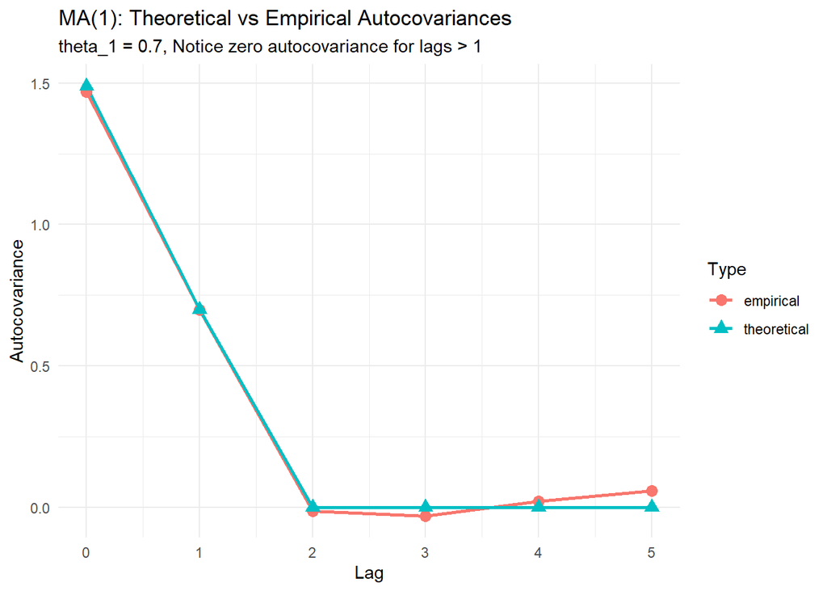

```r
# Plot comparison
comparison_long <- reshape2::melt(comparison_data, id.vars = "lag")

p_comparison <- ggplot(comparison_long, aes(x = lag, y = value, color = variable, shape = variable)) +
  geom_line(size = 1) +
  geom_point(size = 3) +
  labs(title = "MA(1): Theoretical vs Empirical Autocovariances",
       subtitle = "theta_1 = 0.7, Notice zero autocovariance for lags > 1",
       x = "Lag", y = "Autocovariance", color = "Type", shape = "Type") +
  theme_minimal()
print(p_comparison)
```

## MA(2) Process

An MA(2) process follows: $Y_t = \epsilon_t + \theta_1 \epsilon_{t-1} + \theta_2 \epsilon_{t-2}$

**Key properties:** - Mean: $E[Y_t] = 0$ - Variance: $Var(Y_t) = \sigma^2(1 + \theta_1^2 + \theta_2^2)$ - Autocovariance: $\gamma(1) = \sigma^2(\theta_1 + \theta_1\theta_2)$, $\gamma(2) = \sigma^2\theta_2$, $\gamma(k) = 0$ for $k > 2$ - **Finite memory**: depends on current shock and two previous shocks

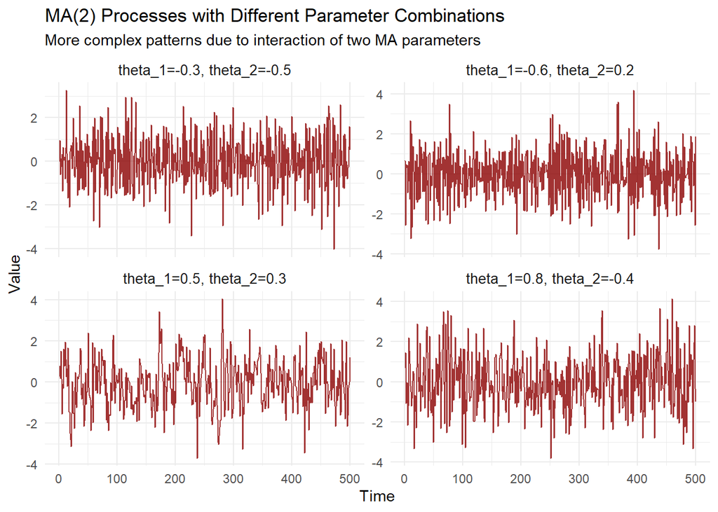

```r
# MA(2) parameters - various combinations
ma2_params <- list(
  list(theta = c(0.5, 0.3), label = "theta_1=0.5, theta_2=0.3"),
  list(theta = c(0.8, -0.4), label = "theta_1=0.8, theta_2=-0.4"),
  list(theta = c(-0.6, 0.2), label = "theta_1=-0.6, theta_2=0.2"),
  list(theta = c(-0.3, -0.5), label = "theta_1=-0.3, theta_2=-0.5")
)

ma2_data <- data.frame()

for (params in ma2_params) {
  series <- simulate_ma(n_obs, params$theta)
  temp_df <- data.frame(
    time = time_points,
    value = series,
    params = params$label,
    process = "MA(2)"
  )
  ma2_data <- rbind(ma2_data, temp_df)
}

# Plot MA(2) processes
p2 <- ggplot(ma2_data, aes(x = time, y = value)) +
  geom_line(color = "darkred", alpha = 0.8) +
  facet_wrap(~params, scales = "free_y", ncol = 2) +
  labs(title = "MA(2) Processes with Different Parameter Combinations",
       subtitle = "More complex patterns due to interaction of two MA parameters",
       x = "Time", y = "Value") +
  theme_minimal() +
  theme(strip.text = element_text(size = 10))

print(p2)
```

## Invertibility Condition for MA Processes

MA processes are **invertible** when they can be written as an infinite AR process. This requires the roots of the characteristic polynomial to lie outside the unit circle.

For MA(1): $1 + \theta_1 z = 0 \Rightarrow$ invertible if $|\theta_1| < 1$ For MA(2): $1 + \theta_1 z + \theta_2 z^2 = 0 \Rightarrow$ more complex conditions

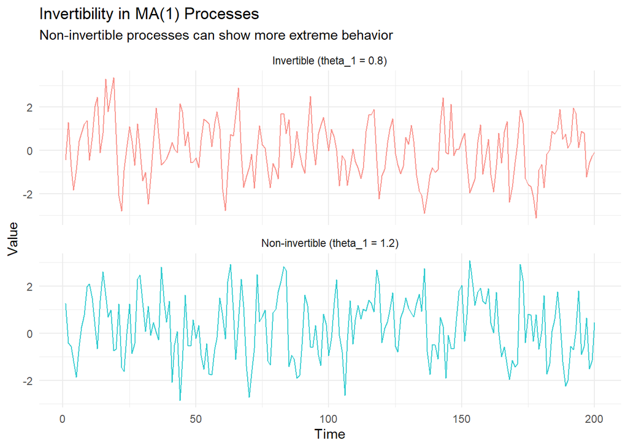

```r
# Demonstrate invertibility concept with MA(1)
# Compare invertible vs non-invertible MA(1)

set.seed(456)
n_demo <- 200

# Invertible MA(1): |theta_1| < 1
inv_series <- simulate_ma(n_demo, 0.8)

# Non-invertible MA(1): |theta_1| > 1
noninv_series <- simulate_ma(n_demo, 1.2)

invertibility_data <- data.frame(
  time = rep(1:n_demo, 2),
  value = c(inv_series, noninv_series),
  invertible = rep(c("Invertible (theta_1 = 0.8)", "Non-invertible (theta_1 = 1.2)"), each = n_demo)
)

p_inv <- ggplot(invertibility_data, aes(x = time, y = value, color = invertible)) +
  geom_line(alpha = 0.8) +
  facet_wrap(~invertible, scales = "free_y", ncol = 1) +
  labs(title = "Invertibility in MA(1) Processes",
       subtitle = "Non-invertible processes can show more extreme behavior",
       x = "Time", y = "Value") +
  theme_minimal() +
  theme(legend.position = "none")

print(p_inv)
```

```r
cat("Variance comparison:\n")
```

```
## Variance comparison:
```

```r
cat("Invertible MA(1):", round(var(inv_series), 3), "\n")
```

```
## Invertible MA(1): 1.624
```

```r
cat("Non-invertible MA(1):", round(var(noninv_series), 3), "\n")
```

```
## Non-invertible MA(1): 1.748
```

## Autocorrelation Analysis: MA vs AR Comparison

One key difference between MA and AR processes is their autocorrelation structure: - **MA(q)**: ACF cuts off after lag q, PACF decays gradually - **AR(p)**: ACF decays gradually, PACF cuts off after lag p

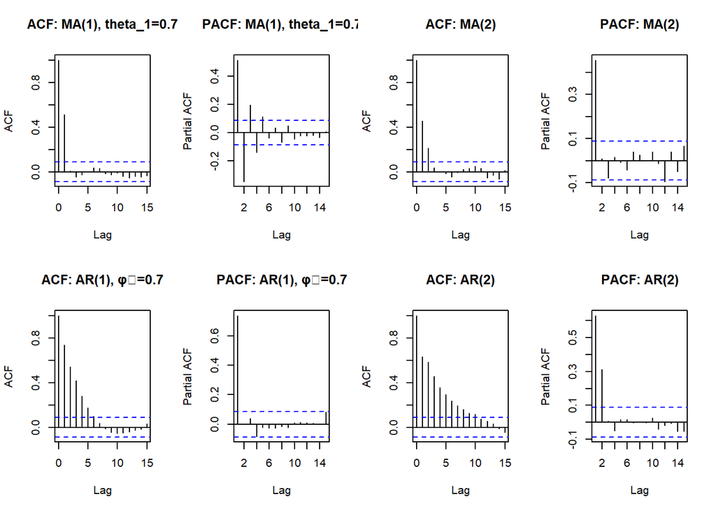

```r
# Compare ACF patterns
par(mfrow = c(2, 4))

# MA(1) with θ = 0.7
ma1_series <- simulate_ma(n_obs, 0.7)
acf(ma1_series, main = "ACF: MA(1), theta_1=0.7", lag.max = 15)
pacf(ma1_series, main = "PACF: MA(1), theta_1=0.7", lag.max = 15)

# MA(2)
ma2_series <- simulate_ma(n_obs, c(0.5, 0.3))
acf(ma2_series, main = "ACF: MA(2)", lag.max = 15)
pacf(ma2_series, main = "PACF: MA(2)", lag.max = 15)

# For comparison: AR(1) and AR(2)
ar1_series <- simulate_ma(n_obs, 0.7) # We'll simulate this differently
ar1_actual <- arima.sim(n = n_obs, list(ar = 0.7))
ar2_actual <- arima.sim(n = n_obs, list(ar = c(0.5, 0.3)))

acf(ar1_actual, main = "ACF: AR(1), φ₁=0.7", lag.max = 15)
pacf(ar1_actual, main = "PACF: AR(1), φ₁=0.7", lag.max = 15)

acf(ar2_actual, main = "ACF: AR(2)", lag.max = 15)
pacf(ar2_actual, main = "PACF: AR(2)", lag.max = 15)
```

```r
par(mfrow = c(1, 1))
```

## MA Process Characteristics Summary

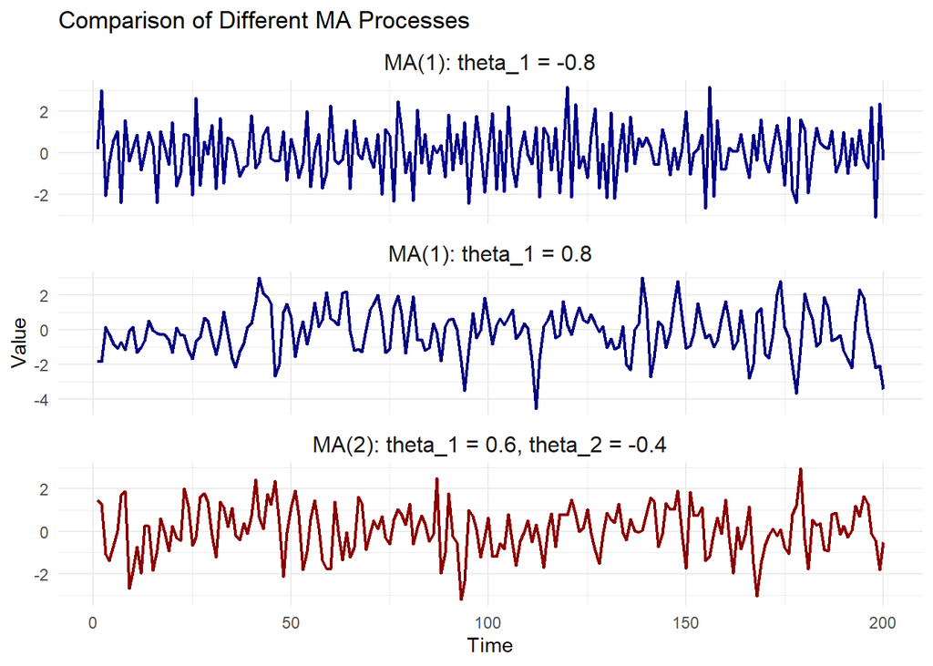

```r
# Create summary comparison
set.seed(789)
n_short <- 200

# Generate different process types
ma1_pos <- simulate_ma(n_short, 0.8)
ma1_neg <- simulate_ma(n_short, -0.8)
ma2_mixed <- simulate_ma(n_short, c(0.6, -0.4))

comparison_data <- data.frame(
  time = rep(1:n_short, 3),
  value = c(ma1_pos, ma1_neg, ma2_mixed),
  process = rep(c("MA(1): theta_1 = 0.8", "MA(1): theta_1 = -0.8", "MA(2): theta_1 = 0.6, theta_2 = -0.4"),
                each = n_short)
)

p_summary <- ggplot(comparison_data, aes(x = time, y = value, color = process)) +
  geom_line(size = 0.8) +
  facet_wrap(~process, scales = "free_y", ncol = 1) +
  scale_color_manual(values = c("darkblue", "navy", "darkred")) +
  labs(title = "Comparison of Different MA Processes",
       x = "Time", y = "Value") +
  theme_minimal() +
  theme(legend.position = "none",
        strip.text = element_text(size = 12))

print(p_summary)
```

```r
# Calculate and display key statistics
cat("\n=== MA PROCESS STATISTICS ===\n")
```

```
##
## === MA PROCESS STATISTICS ===
```

```r
processes <- list(
  "MA(1), theta_1=0.8" = ma1_pos,
  "MA(1), theta_1=-0.8" = ma1_neg,
  "MA(2), theta_1=0.6, theta_2=-0.4" = ma2_mixed
)

for (name in names(processes)) {
  series <- processes[[name]]
  cat(sprintf("%s:\n", name))
  cat(sprintf("  Mean: %.4f\n", mean(series)))
  cat(sprintf("  Variance: %.4f\n", var(series)))
  cat(sprintf("  Lag-1 Autocorr: %.4f\n", cor(series[-1], series[-length(series)])))
  cat("\n")
}
```

```
## MA(1), theta_1=0.8:
##   Mean: -0.1175
##   Variance: 1.7528
##   Lag-1 Autocorr: 0.4562
##
## MA(1), theta_1=-0.8:
##   Mean: 0.0180
##   Variance: 1.6961
##   Lag-1 Autocorr: -0.5336
##
## MA(2), theta_1=0.6, theta_2=-0.4:
##   Mean: 0.0620
##   Variance: 1.2568
##   Lag-1 Autocorr: 0.2629
```

## Key Insights and Practical Applications

### Theoretical Properties Verified:

1. **Stationarity**: All MA processes are stationary by construction
2. **Finite Memory**: MA(q) processes have autocorrelations that are exactly zero for lags > q
3. **Parameter Effects**:
   - Positive θ parameters create smoother series
   - Negative θ parameters create more volatile, oscillating patterns

### Identification Rules:

- **MA(1)**: ACF has one significant lag, then cuts to zero
- **MA(2)**: ACF has two significant lags, then cuts to zero
- **PACF**: Decays gradually for MA processes (opposite of AR)

### Practical Applications:

MA processes are particularly useful for modeling: - **Forecast errors** in econometric models - **Seasonal adjustments** in time series - **Noise filtering** in signal processing - **Short-term dependencies** in financial returns

The finite memory property makes MA models excellent for capturing temporary shocks that affect a system for only a limited time period, unlike AR models which can have persistent effects.

### Model Selection:

Use MA models when: - The autocorrelation function cuts off sharply after q lags - You want to model temporary effects of shocks - The underlying process has a natural “memory length” - Forecast errors show moving average patterns